# Titanic Kaggle

Sergio Rubio

February 16, 2018

# Table of contents

1. Introduction
   1. Context
   2. Challenge
   3. Evaluation
   4. Data
   5. Packages
2. Data understanding
   1. Importing data
   2. Checking data
   3. Describing data
3. Data preparation
   1. Feature engineering
   2. Correlation
4. Modeling
   1. Decision tree
   2. Random forest
5. Evaluation
6. Conclusions

# 1. Introduction

[**Titanic: Machine Learning from Disaster - Kaggle**](https://www.kaggle.com/c/titanic)

The first step of every data project is to have a **clear understanding of the problem** we are trying to solve. In this section we describe the **goal** of the competition and its **rules** and briefly describe the available data.

## 1.1. Context

[figure not shown]

*The sinking of the **RMS Titanic** is one of the most infamous shipwrecks in history. On **April 15, 1912**, during her maiden voyage, the Titanic sank after colliding with an iceberg, **killing 1.502 out of 2.224 passengers and crew**. This sensational tragedy shocked the international community and led to better safety regulations for ships.*

*One of the reasons that the shipwreck led to such loss of life was that there were not enough lifeboats for the passengers and crew. Although there was some element of luck involved in surviving the sinking, **some groups of people were more likely to survive than others**, such as women, children, and the upper-class.*

[Sinking of the RMS *Titanic* - Wikipedia](https://en.wikipedia.org/wiki/Sinking_of_the_RMS_Titanic)

[Titanic sinking - National Geographic](https://www.youtube.com/watch?v=9xoqXVjBEF8)

## 1.2. Challenge

The goal of this competition is to complete the analysis of what sorts of people were likely to survive the sinking. In particular, to apply the tools of machine learning to **predict which passengers survived the tragedy**.

This is a **classification** problem, specifically, a [binary classification](https://en.wikipedia.org/wiki/Binary_classification) problem, because there are only two different states we are classifying.

## 1.3. Evaluation

### Goal

The goal is to **predict if a passenger survived the sinking of the Titanic or not**. For each PassengerId in the test set, the model must predict a 0 or 1 value for the Survived variable.

### Metric

The score is the **percentage of passengers correctly predicted**. This is known simply as “accuracy”.

### Submission File Format

The submission file should be a **csv** file with exactly **418 entries** plus a header row. Submission will show an error if the file has extra columns (beyond PassengerId and Survived) or rows.

The file should have exactly 2 columns:

- **PassengerId** (sorted in any order)
- **Survived** (contains your binary predictions: 1 for survived, 0 for deceased)

```
PassengerId,Survived
 892,0
 893,1
 894,0
 Etc.
```

## 1.4. Data

### Overview

The data has been split into two groups:

- **Training set** (train.csv)
- **Test set** (test.csv)

The **training set** should be used to build the machine learning models. For the training set, each passenger has an outcome (also known as the “ground truth”). The model will be based on “features” like passengers’ gender and class. It is possible to create **new features** using [feature engineering](https://triangleinequality.wordpress.com/2013/09/08/basic-feature-engineering-with-the-titanic-data/).

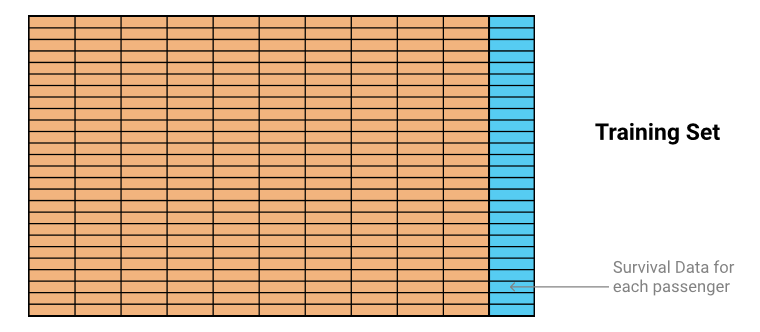

The **test set** should be used to see how well the model performs on unseen data. For the test set, the ground truth for each passenger is not provided. The goal is to **predict**, for each passenger in the test set, whether or not they survived the sinking of the Titanic.

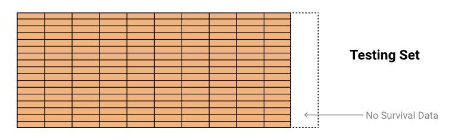

The **gender_submission.csv** file is a set of predictions that assume all and only female passengers survive, as an example of what a submission file should look like.

### Data dictionary

**Variable**: Definition - Key

- **survival**: Survival - (0 = No, 1 = Yes)
- **pclass**: Ticket class - (1 = 1st, 2 = 2nd, 3 = 3rd)
- **sex**: Sex
- **age**: Age in years
- **sibsp**: # of siblings / spouses aboard the Titanic
- **parch**: # of parents / children aboard the Titanic
- **ticket**: Ticket number
- **fare**: Passenger fare
- **cabin**: Cabin number
- **embarked**: Port of Embarkation - (C = Cherbourg, Q = Queenstown, S = Southampton)

### Variable notes

- **pclass**: A proxy for socio-economic status (SES)
  - 1st = Upper
  - 2nd = Middle
  - 3rd = Lower
- **age**: Age is fractional if less than 1. If the age is estimated, is it in the form of xx.5
- **sibsp**: The dataset defines family relations in this way…
  - Sibling = brother, sister, stepbrother, stepsister
  - Spouse = husband, wife (mistresses and fiancés were ignored)
- **parch**: The dataset defines family relations in this way…
  - Parent = mother, father
  - Child = daughter, son, stepdaughter, stepson (Some children travelled only with a nanny, therefore parch=0 for them).

## 1.5. Packages

We need to use several **R packages** for data manipulation, visualization, modeling, etc.

```r
# Load packages

library('dplyr') # Data manipulation
library('ggplot2') # Visualization
library('mice') # Missing values
library('forcats') # Working with factors
library('corrplot') # Correlation matrix
library('rpart') # Decision tree
library('rpart.plot') # Decision tree plot
```

# 2. Data understanding

The second step is to **know the details of the data** we have available to solve the problem. In this section we **load** the datasets, we **check consistency** and we **describe** them in detail.

## 2.1. Importing data

```r
# Load train and test set preventing R to cast strings as factors

train <- read.csv('./data/train.csv', stringsAsFactors=FALSE)
test <- read.csv('./data/test.csv', stringsAsFactors=FALSE)

# Add type of set as a column

train$Set <- "train"
test$Set <- "test"

# Combine train and test sets. "Survived" is filled with NA for the test set

test$Survived <- NA
full <- rbind(train, test)
```

We combine the data from both the train and test set because, when performing **feature engineering**, it’s useful to know the **full range of possible values** and the **distributions of all known values**. We added column `Set` to keep track of the training and test data.

## 2.2. Checking data

### Dimensions

```r
# Check dimensions of imported sets

dim(train)
dim(test)
dim(full)
```

[output not shown]

We confirm that the train set has **891 observations** and the test set has **418 observation** for a total of **1309 observations** as expected.

### Factors

We have to check if all the **categorical variables** are correctly set to [factors](https://www.stat.berkeley.edu/classes/s133/factors.html).

```r
# Structure of the full set

str(full)
```

```
## 'data.frame':    1309 obs. of  13 variables:
##  $ PassengerId: int  1 2 3 4 5 6 7 8 9 10 ...
##  $ Survived   : int  0 1 1 1 0 0 0 0 1 1 ...
##  $ Pclass     : int  3 1 3 1 3 3 1 3 3 2 ...
##  $ Name       : chr  "Braund, Mr. Owen Harris" "Cumings, Mrs. John Bradley (Florence Briggs Thayer)" "Heikkinen, Miss. Laina" "Futrelle, Mrs. Jacques Heath (Lily May Peel)" ...
##  $ Sex        : chr  "male" "female" "female" "female" ...
##  $ Age        : num  22 38 26 35 35 NA 54 2 27 14 ...
##  $ SibSp      : int  1 1 0 1 0 0 0 3 0 1 ...
##  $ Parch      : int  0 0 0 0 0 0 0 1 2 0 ...
##  $ Ticket     : chr  "A/5 21171" "PC 17599" "STON/O2. 3101282" "113803" ...
##  $ Fare       : num  7.25 71.28 7.92 53.1 8.05 ...
##  $ Cabin      : chr  "" "C85" "" "C123" ...
##  $ Embarked   : chr  "S" "C" "S" "S" ...
##  $ Set        : chr  "train" "train" "train" "train" ...
```

Because we imported the datasets with the `stringsAsFactors` parameter set to `FALSE`, we need to convert `Sex`, `Embarked` and `Set` variables **from string to factor**. We also convert `Survived` and `Pclass` variables **from int to factor**.

```r
# Cast variables to factor

factorize <- function(set, columns_to_factor) {
    set_factor <- set
    set_factor[columns_to_factor] <- lapply(select(set, one_of(columns_to_factor)), factor)
    return(set_factor)
}

columns_to_factor <- c("Survived", "Pclass", "Sex", "Embarked", "Set")

full <- factorize(full, columns_to_factor)
train <- factorize(train, columns_to_factor)
test <- factorize(test, columns_to_factor)
```

### Missing values

```r
# Summary of the full set

summary(full)
```

```
##   PassengerId   Survived   Pclass      Name               Sex
##  Min.   :   1   0   :549   1:323   Length:1309        female:466
##  1st Qu.: 328   1   :342   2:277   Class :character   male  :843
##  Median : 655   NA's:418   3:709   Mode  :character
##  Mean   : 655
##  3rd Qu.: 982
##  Max.   :1309
##
##       Age            SibSp            Parch          Ticket
##  Min.   : 0.17   Min.   :0.0000   Min.   :0.000   Length:1309
##  1st Qu.:21.00   1st Qu.:0.0000   1st Qu.:0.000   Class :character
##  Median :28.00   Median :0.0000   Median :0.000   Mode  :character
##  Mean   :29.88   Mean   :0.4989   Mean   :0.385
##  3rd Qu.:39.00   3rd Qu.:1.0000   3rd Qu.:0.000
##  Max.   :80.00   Max.   :8.0000   Max.   :9.000
##  NA's   :263
##       Fare            Cabin           Embarked    Set
##  Min.   :  0.000   Length:1309         :  2    test :418
##  1st Qu.:  7.896   Class :character   C:270    train:891
##  Median : 14.454   Mode  :character   Q:123
##  Mean   : 33.295                      S:914
##  3rd Qu.: 31.275
##  Max.   :512.329
##  NA's   :1
```

From the summary of the dataset we can see that there are several observations with **missing variables** `Age`, `Fare` and/or `Embarked`. Note that the 418 NA’s of the `Survived` variable are from our test set.

Character variables (`Name`, `Ticket` and `Cabin`) might be missing as well and we wouldn’t see it from the summary, because the character representation of a missing value is the **empty character** (“”).

```r
# Count missing values by variable

colSums(is.na(full) | full=='')
```

```
## PassengerId    Survived      Pclass        Name         Sex         Age
##           0         418           0           0           0         263
##       SibSp       Parch      Ticket        Fare       Cabin    Embarked
##           0           0           0           1        1014           2
##         Set
##           0
```

We can plot missing values to show the **missing percentage** over the total number of observations.

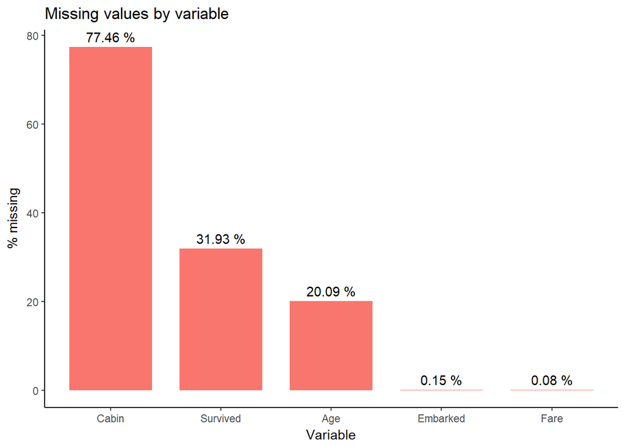

```r
# Bar plot showing % of missing values by variable

data.frame(Perc = (colSums(is.na(full) | full=='')/dim(full)[1])*100, Var = names(full)) %>%
    filter(Perc > 0) %>%
    ggplot(aes(x=reorder(Var, -Perc), y = Perc)) +
    theme_classic() +
    geom_bar(stat='identity', width=0.75, fill="#F8766D") +
    geom_text(aes(label=paste(round(Perc, 2), "%")), vjust=-0.5) +
    labs(x='Variable', y='% missing', title='Missing values by variable')
```

When dealing with missing data it is important to **understand why they are missing**, when possible. Let’s see each case in detail.

- **Cabin**: Titanic cabins were divided by passenger’s class. Cabins **A-D** were assigned for the **1st class**, **E** for the **2nd class** and **F** for the **3rd class**. Cabin **T** was also a **1st class** cabin.

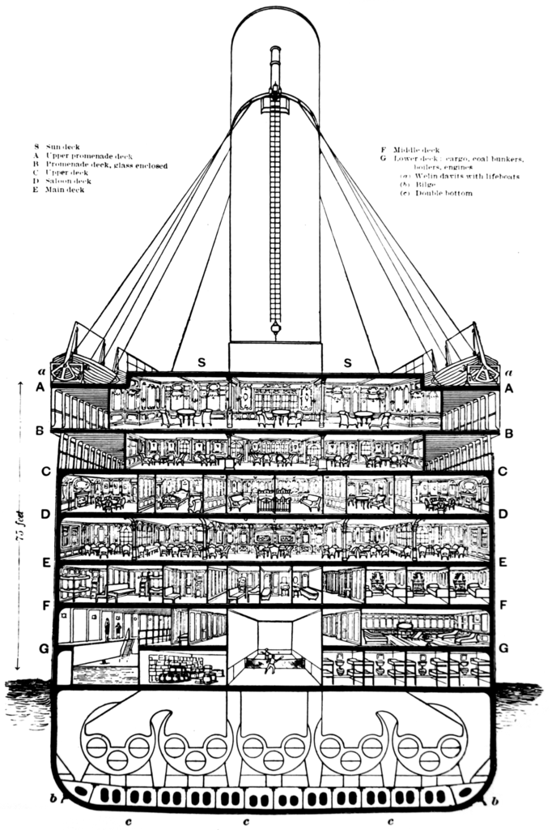

Because of the high percentage of observations without an informed cabin, we can’t just assign the most common cabins to missing values or throw them put. One solution is to **assign a value that indicates a missing**, because the fact that the value is missing can be **useful information** in and of itself.

```r
# Assign "Unknown" value to missing cabins

full$Cabin[full$Cabin == ""] <- "Unknown"
```

- **Embarked**: There were three possible ports of embarkation, **Cherbourg**, **Queenstown**, and **Southampton**.

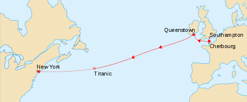

Because there are only 2 observations with a missing `Embarked`, we could **impute the most common embarkation point** to them.

```r
# Get observations with missing Embarked variable

filter(full, Embarked=="")
```

```
##   PassengerId Survived Pclass                                      Name
## 1          62        1      1                       Icard, Miss. Amelie
## 2         830        1      1 Stone, Mrs. George Nelson (Martha Evelyn)
##      Sex Age SibSp Parch Ticket Fare Cabin Embarked   Set
## 1 female  38     0     0 113572   80   B28          train
## 2 female  62     0     0 113572   80   B28          train
```

```r
# Check most common embarkation point

summary(full$Embarked)
```

```
##       C   Q   S
##   2 270 123 914
```

Both observations are 1st class passengers with the **same ticket**. From the summary we know that the most common embarkation point is **Southampton** (**~70%** of passengers), so we impute it to the two observations.

```r
# Impute most common embarked point to observations with missing Embarked variable

full$Embarked[full$Embarked == ""] <- "S"

# Drop empty levels

full$Embarked <- factor(full$Embarked)
```

- **Fare**: With only one observation with missing `Fare`, we can follow the same approach as the `Embarked` case, but this time we will consider more variables for the imputation. Instead of directly impute the average fare, we will use the **median fare for the tickets with the same class and embarked point** than the one we are dealing with. This is because probably the fare of a ticket is mostly influenced by the class and the embarked point.

```r
# Get observations with missing Fare variable

filter(full, is.na(Fare))
```

```
##   PassengerId Survived Pclass               Name  Sex  Age SibSp Parch
## 1        1044     <NA>      3 Storey, Mr. Thomas male 60.5     0     0
##   Ticket Fare   Cabin Embarked  Set
## 1   3701   NA Unknown        S test
```

The passenger has a **3rd class** ticket from **Southampton**. We get the median fare for 3rd class tickets from Southampton and assign it to the observation.

```r
# Median fare by class and embarked point

full %>%
    group_by(Pclass, Embarked) %>%
    summarise(count = n(), median_fare = median(Fare, na.rm=TRUE))
```

```
## # A tibble: 9 x 4
## # Groups:   Pclass [?]
##   Pclass Embarked count median_fare
##   <fct>  <fct>    <int>       <dbl>
## 1 1      C          141       76.7
## 2 1      Q            3       90.0
## 3 1      S          179       52.0
## 4 2      C           28       15.3
## 5 2      Q            7       12.4
## 6 2      S          242       15.4
## 7 3      C          101        7.90
## 8 3      Q          113        7.75
## 9 3      S          495        8.05
```

```r
# Assign median fare by class and embarked point to observations with missing fare

full <- full %>%
            group_by(Pclass, Embarked) %>%
            mutate(Fare = ifelse(is.na(Fare), round(median(Fare, na.rm = TRUE), 4), Fare))
```

- **Age**: Variable `Age` has a relative high percentage of missings. One common way to deal with missing nominal variables is to **asign the average value to the missings**. This is a simple approach, but it’s only recommended for variables that aren’t really important, and probably in our case `Age` is one of the most important variables.

A more complex approach is to **use a regression or another model to predict the missings**. We can apply this approach by using the [MICE package](https://datascienceplus.com/imputing-missing-data-with-r-mice-package/).

```r
# Get Predictor-Matrix
init = mice(full, maxit=0, print=FALSE)
predM = init$predictorMatrix

# Filter what columns not to use to impute the values
predM[, c("PassengerId", "Name","Ticket","Cabin")]=0
imp <- mice(full, m=5, predictorMatrix = predM, print=FALSE)

# Get set with imputed age values filled
full_imp <- complete(imp)
```

```r
# Keep original Survived column and remove temporal full_imp set

full_imp$Survived <- full$Survived
full <- full_imp
rm(full_imp)
```

## 2.3. Describing data

In this section we will **look at the data** in as many different ways as possible. This is called [Exploratory Data Analysis (EDA)](https://en.wikipedia.org/wiki/Exploratory_data_analysis), and it’s an approach to **summarize the main characteristics of the dataset**, often with visual methods.

```r
# Subset of full set containing only train data

full_tr <- filter(full, Set=="train")
```

We use the subset of train data from our full set because we need `Survived` informed and we want to **keep the imputations of missings** from the previous section.

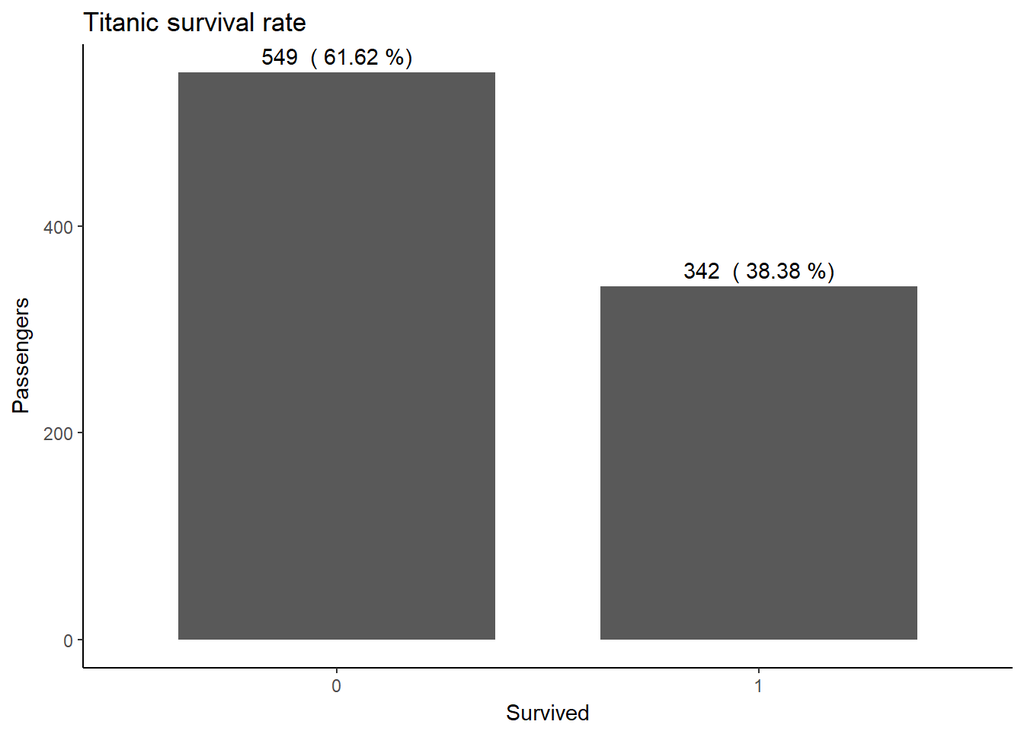

```r
# Bar plot of the general survival rate

ggplot(full_tr, aes(x = Survived)) +
    theme_classic() +
    geom_bar(width = 0.75) +
    geom_text(stat='count', aes(label=paste(..count..," (",(round((..count../sum(..count..))*100, 2)), "%)"),vjust=-0.5)) +
    labs(x='Survived', y='Passengers', title='Titanic survival rate')
```

Only **342 passengers of the 891** from the trainning set survived, a **38.38%** rate.

### Hypothesis

Before we start looking for relationships in the data, we should **formulate some hypothesis**.

[*Women and children first*](https://en.wikipedia.org/wiki/Women_and_children_first) is a code of conduct famously associated with the sinking of Titanic, where survival resources such as **lifeboats were limited**.

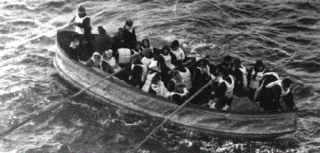

Another common hypothesis is that **rich passengers survival rate is higher than poor passengers**. A possible explanation for this is the **cabins location**; 1st class cabins were at the top level while 3rd class were at the bottom, making it hard to reach the lifeboats.

We can start then with the following hypothesis:

- **Women survival rate is higher than men**.
- **Children and young passengers survival rate is higher than adults**.
- **Rich passengers survival rate is higher than poor passengers**.

### Relationships

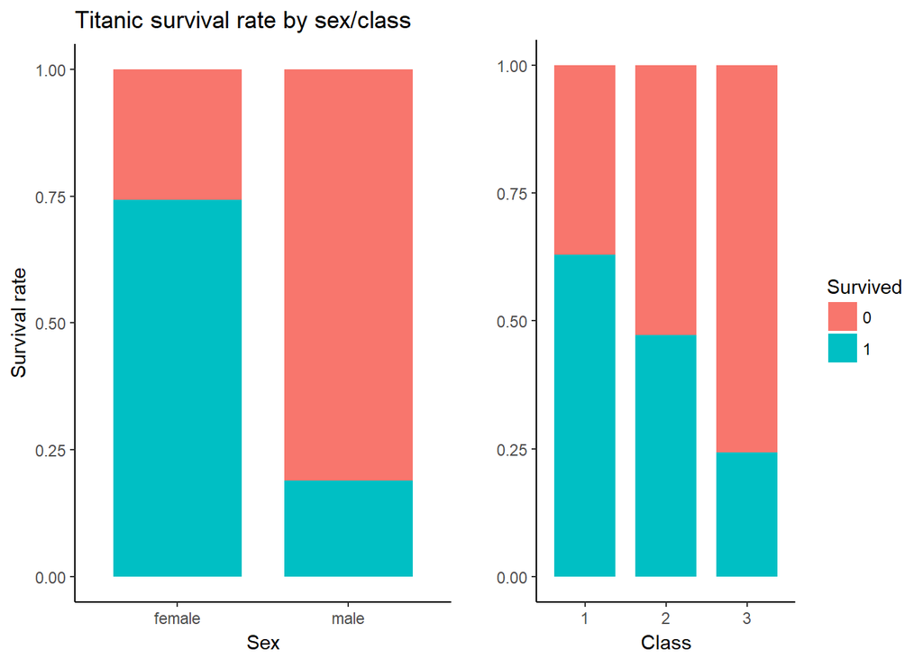

```r
# Bar plot survival rate by sex

surv_sex <- ggplot(full_tr, aes(x=Sex, fill=Survived)) +
    theme_classic() +
    geom_bar(stat='count', width=0.75, position='fill') +
    labs(x='Sex', y='Survival rate', title='Titanic survival rate by sex/class') +
    guides(fill=FALSE)

# Bar plot survival rate by passenger class

surv_class <- ggplot(full_tr, aes(x=Pclass, fill=Survived)) +
    theme_classic() +
    geom_bar(stat='count', width=0.75, position='fill') +
    labs(x='Class', y='', title='')

Rmisc::multiplot(surv_sex, surv_class, cols=2)
```

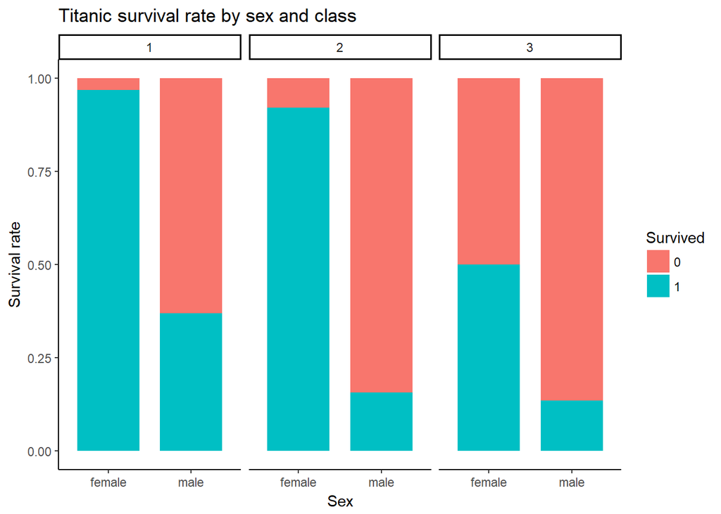

```r
# Bar plot survival rate by sex and passenger class

ggplot(full_tr, aes(x=Sex, fill=Survived)) +
    theme_classic() +
    geom_bar(stat='count', width=0.75, position='fill') +
    facet_wrap(~Pclass) +
    labs(x='Sex', y='Survival rate', title='Titanic survival rate by sex and class')
```

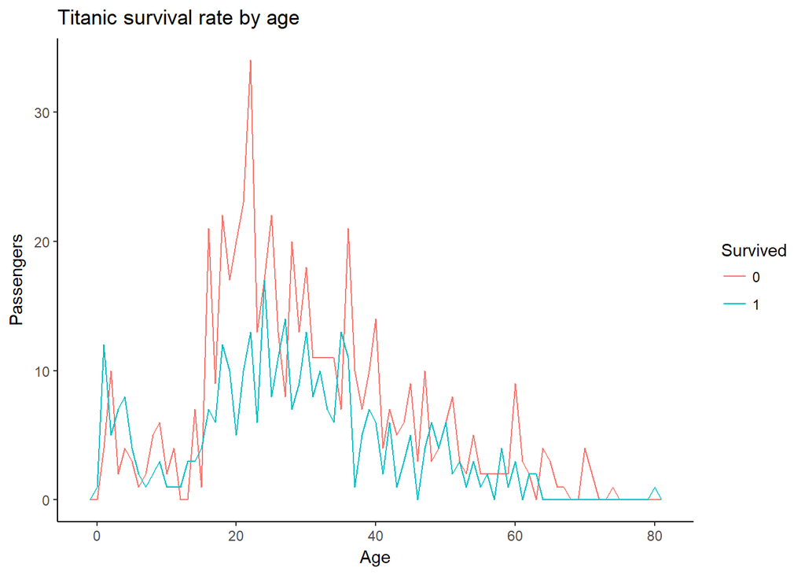

```r
ggplot(full_tr) +
    theme_classic() +
    geom_freqpoly(aes(x = Age, color = Survived), binwidth = 1) +
    labs(x='Age', y='Passengers', title='Titanic survival rate by age')
```

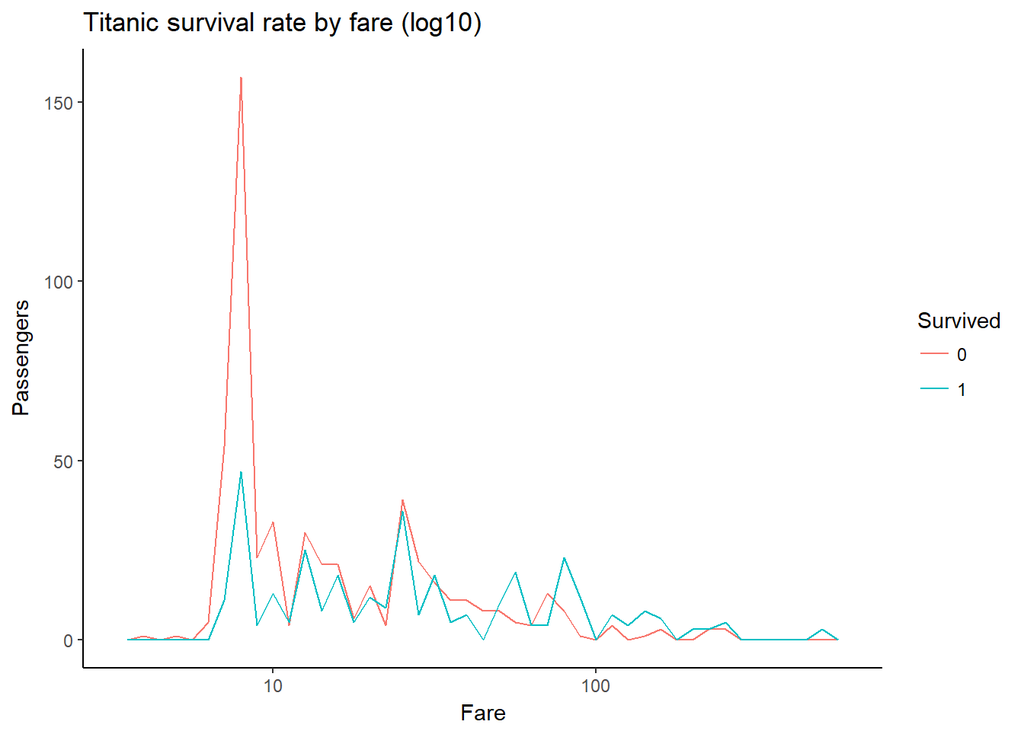

```r
ggplot(full_tr) +
    theme_classic() +
    geom_freqpoly(aes(x = Fare, color = Survived), binwidth = 0.05) +
    scale_x_log10() +
    labs(x='Fare', y='Passengers', title='Titanic survival rate by fare (log10)')
```

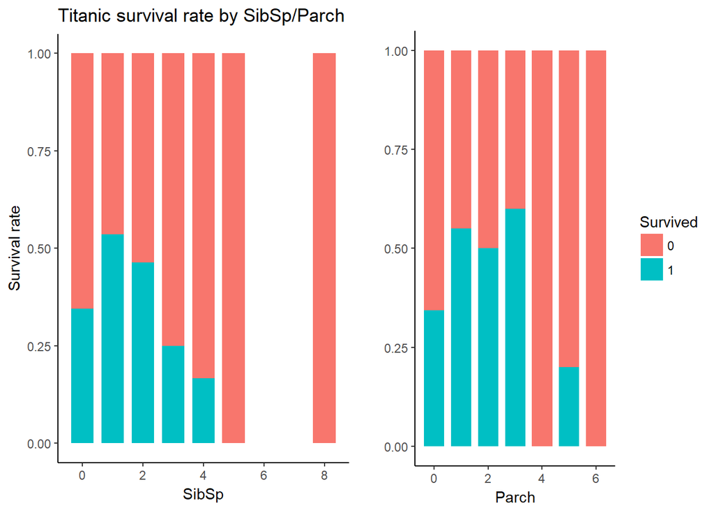

```r
# Bar plot survival rate by SibSp

surv_sibsp <- ggplot(full_tr, aes(x=SibSp, fill=Survived)) +
    theme_classic() +
    geom_bar(stat='count', width=0.75, position='fill') +
    labs(x='SibSp', y='Survival rate', title='Titanic survival rate by SibSp/Parch') +
    guides(fill=FALSE)

# Bar plot survival rate by Parch

surv_parch <- ggplot(full_tr, aes(x=Parch, fill=Survived)) +
    theme_classic() +
    geom_bar(stat='count', width=0.75, position='fill') +
    labs(x='Parch', y='', title='')

Rmisc::multiplot(surv_sibsp, surv_parch, cols=2)
```

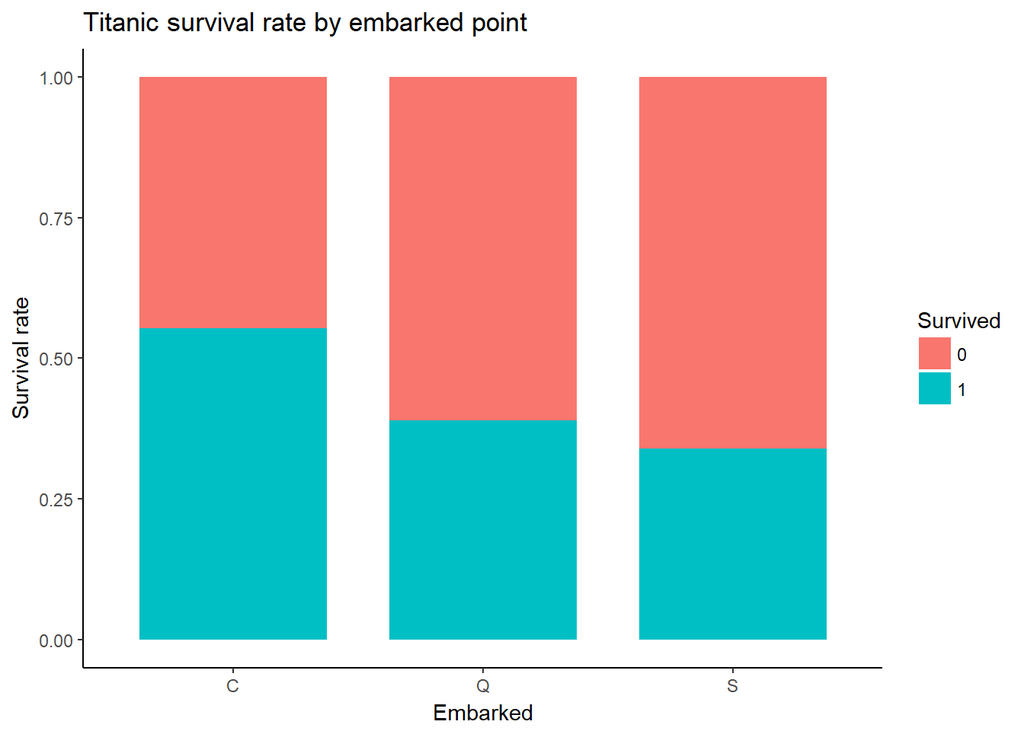

```r
# Bar plot survival rate by embarked point

ggplot(full_tr, aes(x=Embarked, fill=Survived)) +
    theme_classic() +
    geom_bar(stat='count', width=0.75, position='fill') +
    labs(x='Embarked', y='Survival rate', title='Titanic survival rate by embarked point')
```

# 3. Data preparation

In this section we prepare our dataset for the modelling step, **adding or removing features** (variables).

## 3.1. Feature engineering

One way to improve the results of a machine learning algorithm is to **create additional relevant features** from the existing features in the data. This process is called [feature engineering](https://en.wikipedia.org/wiki/Feature_engineering).

### Title

If we take a look to the name variable we can see that it contains the **title of the passenger** (Mr., Mrs, etc.).

```r
# Top observations of Name variable

head(full$Name)
```

```
## [1] "Braund, Mr. Owen Harris"
## [2] "Cumings, Mrs. John Bradley (Florence Briggs Thayer)"
## [3] "Heikkinen, Miss. Laina"
## [4] "Futrelle, Mrs. Jacques Heath (Lily May Peel)"
## [5] "Allen, Mr. William Henry"
## [6] "Moran, Mr. James"
```

That could be relevant information, we can create the `Title` feature from the name.

```r
# Create Title feature from the Name variable

full <- full %>%
    mutate(Title = sub("^.*, (.*?)\\..*$", "\\1", Name))


# Count passengers by Title

full %>%
    group_by(Title) %>%
    summarise(Count = n()) %>%
    mutate(Freq = round(Count/sum(Count),2)) %>%
    arrange(desc(Count))
```

```
## # A tibble: 18 x 3
##    Title        Count   Freq
##    <chr>        <int>  <dbl>
##  1 Mr             757 0.580
##  2 Miss           260 0.200
##  3 Mrs            197 0.150
##  4 Master          61 0.0500
##  5 Dr               8 0.0100
##  6 Rev              8 0.0100
##  7 Col              4 0.
##  8 Major            2 0.
##  9 Mlle             2 0.
## 10 Ms               2 0.
## 11 Capt             1 0.
## 12 Don              1 0.
## 13 Dona             1 0.
## 14 Jonkheer         1 0.
## 15 Lady             1 0.
## 16 Mme              1 0.
## 17 Sir              1 0.
## 18 the Countess     1 0.
```

As we can see, Mr, Miss and Mrs are taking more than **93%** of the values, Master the **5%** and the rest the remaining **2%**. We group this last remaining group to other titles.

```r
# Replace less frequent titles with more frequent ones

full <- full %>%
    mutate(Title = factor(case_when(
        Title %in% c("Mlle","Ms","Lady","Dona") ~ "Miss",
        Title == 'Mme' ~ 'Mrs',
        Title %in% c('Capt','Col','Major','Dr','Rev','Don','Sir','the Countess','Jonkheer') ~ 'Officer',
        TRUE ~ Title
    )))
```

Let’s check the survival rate by our new `Title` feature.

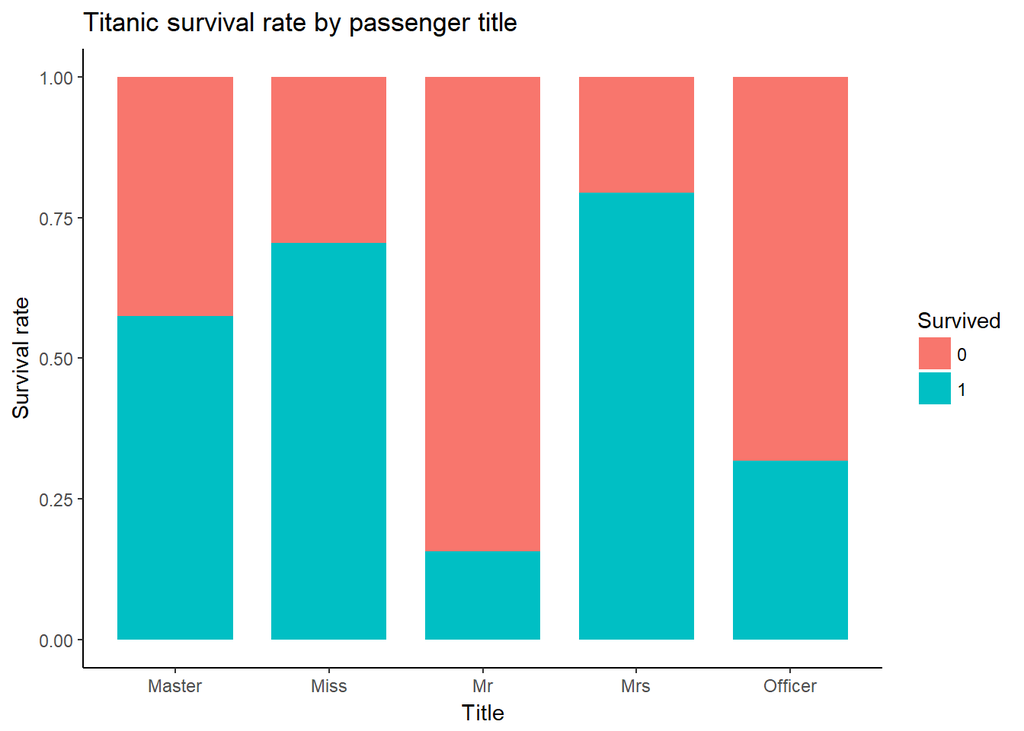

```r
# Bar plot survival rate by passenger title

ggplot(filter(full, Set=='train'), aes(x=Title, fill=Survived)) +
    theme_classic() +
    geom_bar(stat='count', width=0.75, position='fill') +
    labs(x='Title', y='Survival rate', title='Titanic survival rate by passenger title')
```

### Age

From the age variable we can create a **group age feature** that could be more useful than the raw age value.

```r
# Add age group feature

full <- full %>%
    mutate(Age_group = factor(case_when(
        Age < 5 ~ 'Infant',
        Age >= 5 & Age < 12 ~ 'Child',
        Age >= 12 & Age < 18 ~ 'Teenager',
        Age >= 18 & Age < 35 ~ 'Young adult',
        Age >= 35 & Age < 60 ~ 'Adult',
        Age >= 60 ~ 'Senior'
    )))
```

We check the survival rate by age group.

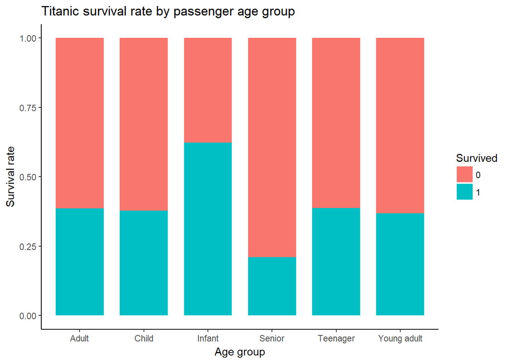

```r
# Bar plot survival rate by passenger age group

ggplot(filter(full, Set=='train'), aes(x=Age_group, fill=Survived)) +
    theme_classic() +
    geom_bar(stat='count', width=0.75, position='fill') +
    labs(x='Age group', y='Survival rate', title='Titanic survival rate by passenger age group')
```

### Family

From `SibSp` and `Parch` variables we can derive the **number of family members** for each passenger.

```r
# Add family size and family type features

full$Family_size <- full$SibSp + full$Parch + 1

full <- full %>%
    mutate(Family_type = factor(case_when(
        Family_size == 1 ~ 'Single',
        Family_size >= 2 & Family_size <= 4 ~ 'Small',
        Family_size >= 5 ~ 'Big'
    )))
```

We can now check the survival rate by family size.

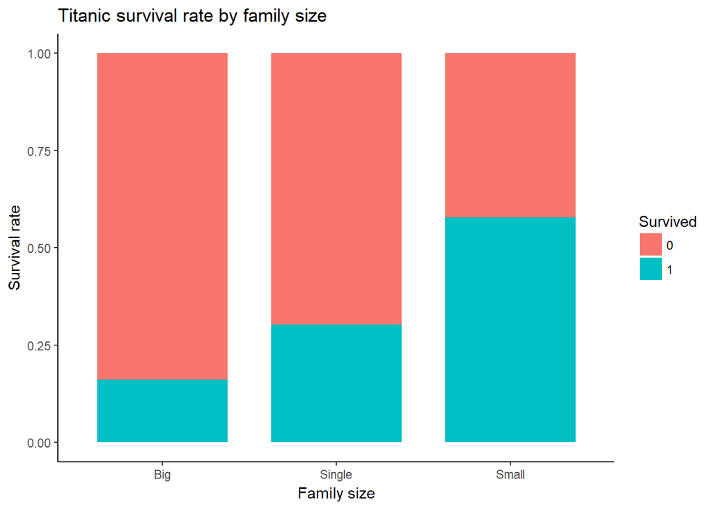

```r
# Bar plot survival rate by passenger family size

ggplot(filter(full, Set=='train'), aes(x=Family_type, fill=Survived)) +
    theme_classic() +
    geom_bar(stat='count', width=0.75, position='fill') +
    labs(x='Family size', y='Survival rate', title='Titanic survival rate by family size')
```

### Ticket

Checking the ticket variable we can see that some passengers **shared the same ticket number**.

```r
# Summary of tickets by number of passengers

full %>%
    group_by(Ticket) %>%
    summarise(Count = n()) %>%
    group_by(Count) %>%
    summarise(Count_size = n()) %>%
    mutate(Freq_size = round(Count_size/sum(Count_size),2)) %>%
    arrange(desc(Count_size))
```

```
## # A tibble: 9 x 3
##   Count Count_size Freq_size
##   <int>      <int>     <dbl>
## 1     1        713    0.770
## 2     2        132    0.140
## 3     3         49    0.0500
## 4     4         16    0.0200
## 5     5          7    0.0100
## 6     7          5    0.0100
## 7     6          4    0.
## 8     8          2    0.
## 9    11          1    0.
```

This summary shows that only **77% of the tickets belonged to one single passenger**, 14% were shared by two passengers, 5% by 3, etc.

We will replicate the approach of the `Family_size` variable adding the `Ticket_size` feature.

```r
# Add ticket size and ticket type features

full <- full %>%
    group_by(Ticket) %>%
    summarise(Ticket_size = n()) %>%
    inner_join(full, by='Ticket') %>%
    mutate(Ticket_type = factor(case_when(
        Ticket_size == 1 ~ 'Single',
        Ticket_size >= 2 & Ticket_size <= 4 ~ 'Small',
        Ticket_size >= 5 ~ 'Big'
    )))
```

Let’s check the survival rate by the new `Ticket_type` feature.

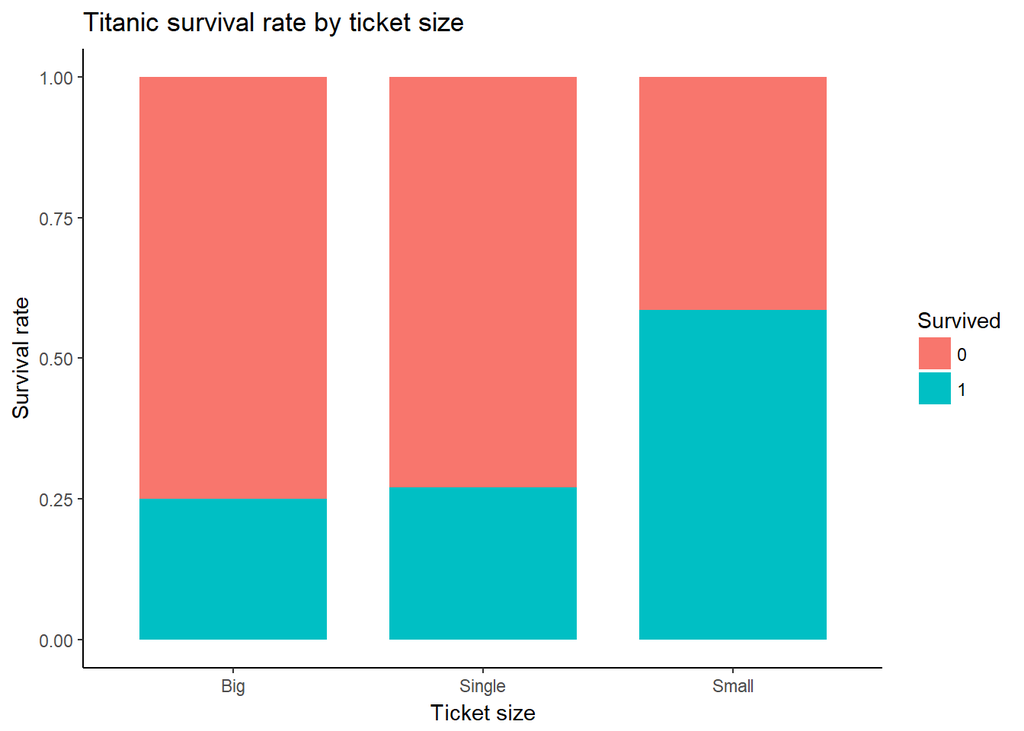

```r
# Bar plot survival rate by passenger family size
ggplot(filter(full, Set=='train'), aes(x=Ticket_type, fill=Survived)) +
    theme_classic() +
    geom_bar(stat='count', width=0.75, position='fill') +
    labs(x='Ticket size', y='Survival rate', title='Titanic survival rate by ticket size')
```